# Reproducible Research: Peer Assessment 1

## Loading and preprocessing the data

I use read.csv to load the data from the activity.csv file with specifying the column classes.

```r
data <- read.csv("activity.csv", colClasses = c("integer", "Date", "integer"))
```

## What is mean total number of steps taken per day?

### Calculate the total number of steps taken per day

I try to use dplyr libray to group daily total steps

```r
library(dplyr)
totalsteps<- data %>% group_by(date) %>% summarize(totalsteps = sum(steps))
totalsteps
```

```
## Source: local data frame [61 x 2]
##
##          date totalsteps
## 1  2012-10-01         NA
## 2  2012-10-02        126
## 3  2012-10-03      11352
## 4  2012-10-04      12116
## 5  2012-10-05      13294
## 6  2012-10-06      15420
## 7  2012-10-07      11015
## 8  2012-10-08         NA
## 9  2012-10-09      12811
## 10 2012-10-10       9900
## ..        ...        ...
```

### Make a histogram of the total number of steps taken each day

In order to observe the distribution of the total steps per day, I draw the histogram of the total steps per day.

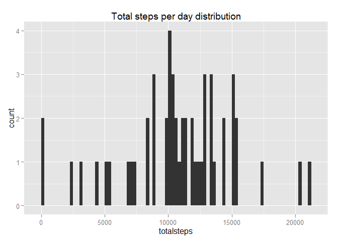

```r
library(ggplot2)
ggplot(totalsteps, aes(totalsteps)) + geom_histogram(binwidth = 250) +
labs(title = "Total steps per day distribution")
```

### Mean and median of the total number of steps taken per day

```r
mean <- as.integer(round(mean(totalsteps$totalsteps, na.rm =TRUE)))
median <- median(totalsteps$totalsteps, na.rm =TRUE)
```

The mean of total number of steps taken per day is 10766. The median of total number of steps taken per day is 10765

## What is the average daily activity pattern?

### Time series plot

In order to observe daily activity, I make a time series plot.

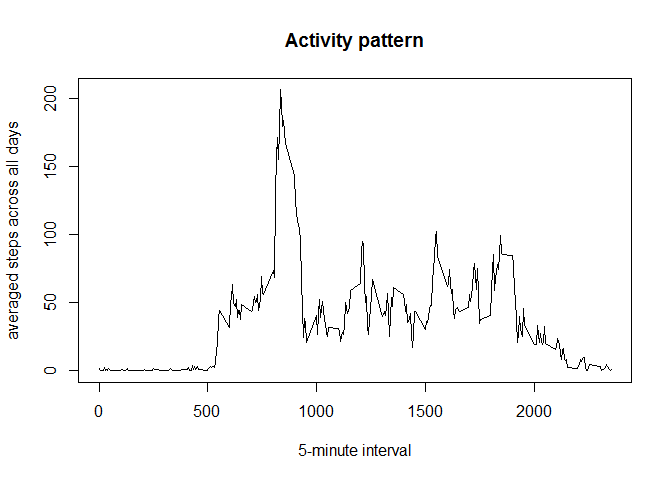

```r
intervalsteps <- data %>% group_by(interval) %>%
     summarize(averagesteps = mean(steps, na.rm =TRUE))
plot(intervalsteps$interval, intervalsteps$averagesteps, type = "l",
     xlab="5-minute interval", ylab = "averaged steps across all days", main = "Activity pattern")
```

### 5-minute interval contains the maximum number of steps

I also observe which interval contains the maximum number of steps.

```r
max <- intervalsteps[which.max(intervalsteps$averagesteps),]
max.interval <- max$interval
max.steps <- max$averagesteps
```

As you can see from the diagram, the 5-minute interval which contains the maximum number of step is 835 interval. This interval contains 206.1698113 steps.

## Imputing missing values

### Total number of missing values in the dataset

I found there are a lot of NA in the steps column, but there is no NA in date and interval column.  
I decide to calculate how many missing values in the dataset.

```r
missing.num<- sum(is.na(data$steps))
```

There are 2304 rows with NA in the dataset

### A strategy for filling in all of the missing values

I decide to use mean for that 5-minute interval to fill in the missing values.

### Create a new dataset that is equal to the original dataset but with the missing data filled in.

```r
newdata <- data %>% group_by(interval) %>% mutate(steps =
ifelse(is.na(steps),intervalsteps[which(intervalsteps$interval == interval[1]),]$averagesteps,
       steps))
```

### total number of steps taken each day

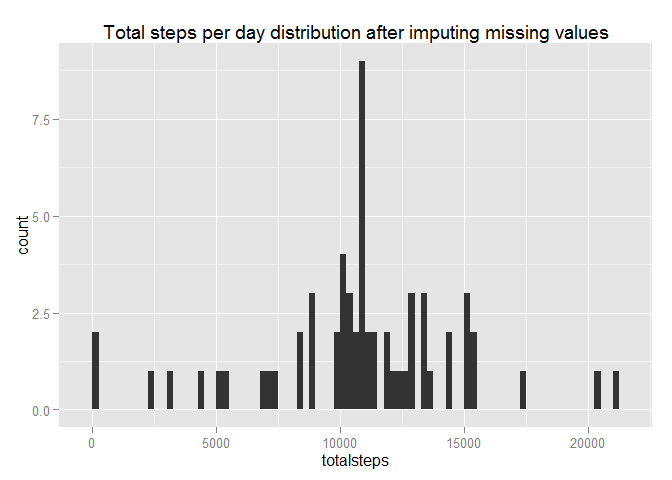

```r
totalsteps<- newdata %>% group_by(date) %>% summarize(totalsteps = sum(steps))
ggplot(totalsteps, aes(totalsteps)) + geom_histogram(binwidth = 250) +
labs(title = "Total steps per day distribution after imputing missing values")
```

```r
mean <- as.integer(round(mean(totalsteps$totalsteps, na.rm =TRUE)))
median <- median(totalsteps$totalsteps, na.rm =TRUE)
```

## Are there differences in activity patterns between weekdays and weekends?

### Create a new factor variable in the dataset with two levels

We create a new column named day with two label: weekday and weekend

```r
Sys.setlocale("LC_TIME", "US")
```

```
## [1] "English_United States.1252"
```

```r
data$day <-factor(1* (weekdays(data$date) != "Sunday" &
            weekdays(data$date)!= "Saturday"), labels = c("weekend", "weekday"))
```

### panel plot grouped by weekend and weekday label

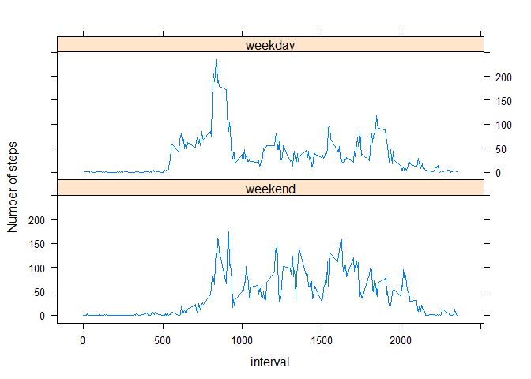

```r
week.data<- data %>% group_by(day,interval) %>% summarize(averagesteps = mean(steps, na.rm =TRUE))
library(lattice)
xyplot( averagesteps ~ interval|day, data = week.data, layout = c(1, 2),
        type = "l", ylab = "Number of steps")
```